# Análisis de Componentes Principales

Wilson Sandoval

2024-02-16

# **Análisis de Componentes Principales (ACP)**

**Principal Component Analysis (PCA):** método estadístico que permite simplificar la complejidad de espacios muestrales con muchas dimensiones a la vez que conserva su información.

- Dada una muestra de $n$ individuos cada uno con $p$ variables $(X_1, X_2, …, X_p)$, es decir, el espacio muestral tiene $p$ dimensiones.
- El PCA permite encontrar un número de factores subyacentes $(z<p)$ que explican aproximadamente lo mismo que las $p$ variables originales.
- Cada $z$ recibe el nombre de componente principal.
- Una de las aplicaciones de PCA es la reducción de dimensionalidad (variables), perdiendo la menor cantidad de información (varianza) posible:
- El PCA sirve como herramienta para la visualización de datos

El análisis en componentes principales (ACP) se utiliza para describir tablas que tienen en las filas las unidades estadísticas, generalmente denominadas, **“individuos”**, y en las columnas las **variables de tipo continuo** que se han medido sobre los individuos.

Los objetivos del ACP son:

- Comparar los individuos entre si. Las gráficas que se obtienen permiten observar la forma de la “nube de individuos”, lo que a su vez permite detectar patrones en ellos.
- Describir las relaciones entre las variables.
- Reducir la dimensión de la representación. A mayor relación entre las variables mayor es la capacidad de síntesis del ACP y unos pocos ejes factoriales podrán resumir las variables originales.

# Eingenvectores y eigenvalores

Los eigenvectores y eigenvalores son números y vectores asociados a matrices cuadradas. Dada una matriz $A$ de $n\times n$, su eigenvector $v$ de $n $ tal que

$$Av =\lambda v$$

- $\lambda$ es el eigenvalor, un valor escalar real asociado con el eigenvector.

Ejemplo:

$$\begin{pmatrix} 2 & 3 \\ 2 & 1
\end{pmatrix} \begin{pmatrix} 3 \\ 2 \end{pmatrix} = \begin{pmatrix} 12
\\ 8 \end{pmatrix} = 4 \begin{pmatrix} 3 \\ 2
\end{pmatrix}$$

en R los puede calcular con la funcion `eigen`

**Ejercicio:**

- Defina la matriz y guardela con el nombre $B$

```r
B=matrix(c(2,3,2,1), nrow=2, byrow = T)
B
```

```
##      [,1] [,2]
## [1,]    2    3
## [2,]    2    1
```

- Calcular los eingevalores y eingevectores

```r
eigen(B)
```

```
## eigen() decomposition
## $values
## [1]  4 -1
##
## $vectors
##           [,1]       [,2]
## [1,] 0.8320503 -0.7071068
## [2,] 0.5547002  0.7071068
```

## Estandarización de las Variables

- El cálculo de los componentes principales depende de las unidades de medida empleadas en las variables.
- Es importante, antes de aplicar el PCA, estandarizar las variables para que tengan media 0 y desviación estándar 1

$$\frac{x_i−media(x)}{sd(x)}$$

## Interpretación geométrica de las componentes principales

Una forma intuitiva de entender el proceso de PCA consiste en interpretar las componentes principales desde un punto de vista geométrico.

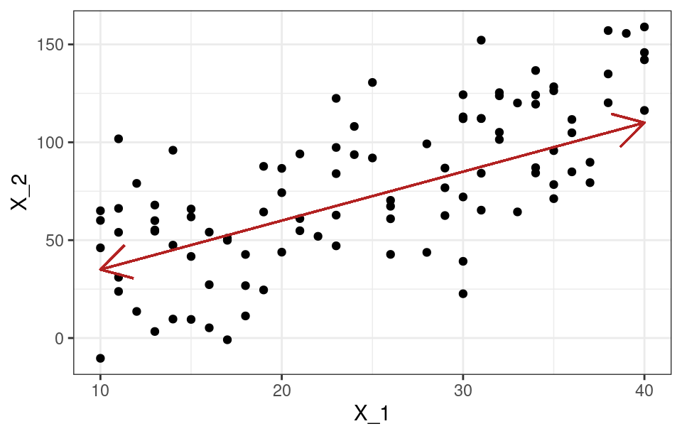

## Cálculo de las componentes principales

- Cada componente principal ($Z_i$) se obtiene por combinación lineal de las variables originales.
- La primera componente principal de un grupo de variables $(X_1, X_2, …, X_p)$ es la combinación lineal normalizada de dichas variables que tiene mayor varianza:

$$Z_1=\phi_{11} X_1 + \phi_{21}X_2+ ... +
\phi_{p1}X_p$$
con la condición

$$\displaystyle\sum_{j=1}^p \phi^{2}_{j1}=
1$$
En general
$$Z_{m}=\sum_{j=1}^{p} \phi_{j m} X_{j}$$

- $\phi_{1m},\phi_{2m},...,\phi_{pm}$ son las cargas o `loadings` de los componentes principales
- La primera componente principal ($Z_1$) es aquella cuya dirección refleja o contiene la mayor variabilidad en los datos.
- Este vector define la línea lo más próxima posible a los datos y que minimiza la suma de las distancias perpendiculares entre cada dato y la línea representada por la componente (usando como medida de cercanía el promedio de la distancia euclídea al cuadrado):

$$z_{i1}=\phi_{11} x_{i 1}+\phi_{21} x_{i 2}+\ldots+\phi_{p 1} x_{i p}$$
donde $\phi_{11}$ corresponde al primer loading de la primera componente principal.

En otras palabras, el vector de loadings de la primera componente principal resuelve el problema de optimización

$$\underset{\phi_{11}, \ldots, \phi_{p
1}}{\operatorname{maximize}}\left\{\frac{1}{n}
\sum_{i=1}^{n}\left(\sum_{j=1}^{p} \phi_{j 1} x_{i j}\right)^{2}\right\}$$
$$\text { sujeto a }
\sum_{j=1}^{p} \phi_{j 1}^{2}=1$$
- La segunda componente principal ($Z_2$) será una combinación lineal de las variables, que recoja la segunda dirección con mayor varianza de los datos, pero que no esté correlacionada con $Z_1$. Esta condición es equivalente a decir que la dirección de $Z_2$ (vector $\phi_{2}$) ha de ser perpendicular u ortogonal respecto a $Z_1$ (vector $\phi_1$).

## Proporción de la varianza explicada

- **¿Cuánta información presente en el set de datos original se pierde al proyectar las observaciones en un espacio de menor dimensión?**
- **¿Cuanta información es capaz de capturar cada una de las componentes principales obtenidas?**

Asumiendo que las variables se han normalizado para tener media cero, la varianza total presente en el set de datos se define como

$$\displaystyle\sum_{j=1}^p Var(X_j) =
\displaystyle\sum_{j=1}^p \frac{1}{n} \displaystyle\sum_{i=1}^n
x^{2}_{ij}$$

la varianza explicada por la componente $m$ es:

$$\frac{1}{n} \sum_{i=1}^n z^{2}_{im} =
\frac{1}{n} \sum_{i=1}^n \left( \sum_{j=1}^p \phi_{jm}x_{ij}
\right)^2$$
La proporción de varianza explicada por la componente $m$ es:

$$\frac{\sum_{i=1}^n \left( \sum_{j=1}^p
\phi_{jm}x_{ij} \right)^2} {\sum_{j=1}^p \sum_{i=1}^n
x^{2}_{ij}}$$

### Algunos comandos en R

- `library(stats)`
  - `prcomp()` -> Forma rápida de implementar PCA sobre una matriz de datos.
  - `princomp()`
- `library(FactoMineR)`
  - `PCA()` -> PCA con resultados más detallados.
  - Los valores ausentes se reemplazan por la media de cada columna.
  - Pueden incluirse variables categóricas suplementarias.
  - Estandariza automáticamente los datos.
- `library(factoextra)`
  - `get_pca()` -> Extrae la información sobre las observaciones y variables de un análisis PCA.
  - `get_pca_var()` -> Extrae la información sobre las variables.
  - `get_pca_ind()` -> Extrae la información sobre las observaciones.

#### Visualizaciones:

- `library(FactoMineR)`
  - `fviz_pca_ind()` -> Representación de observaciones sobre componentes principales.
  - `fviz_pca_var()` -> Representación de variables sobre componentes principales.
  - `fviz_screeplot()` -> Representación (gráfico barras) de eigenvalores.
  - `fviz_contrib()` -> Representa la contribución de filas/columnas de los resultados de un pca.

| Matrix | Alien | Serenity | Casablanca | Amelie |
| --- | --- | --- | --- | --- |
| 1 | 1 | 1 | 0 | 0 |
| 3 | 3 | 3 | 0 | 0 |
| 4 | 4 | 4 | 0 | 0 |
| 5 | 5 | 5 | 0 | 0 |
| 0 | 2 | 0 | 4 | 4 |
| 0 | 0 | 0 | 5 | 5 |
| 0 | 1 | 0 | 2 | 2 |

Realice análisis de componentes de componentes principales para la base de películas y usuarios usando los paquetes “FACTO”

- **Ejercicio:**

Defina una matriz llamela $A$, los nombres de las columnas “Matrix”, “Alien”, “Serenity”,“Casablanca”, “Amelie” nombres de los individuos “Pedro”,“Adriana”, “Teo”, “Andres”, “Manuel”, “Javier”, “Maria”

```r
data=c(1,   1,  1,  0,  0,3,    3,  3,  0,  0,4,    4,  4,  0,  0,5,    5,  5,  0,
       0,0, 2,  0,  4,  4,0,    0,  0,  5,  5,0,    1,  0,  2,  2)
A=matrix(data, nrow=7, byrow = T)
peliculas=c("Matrix", "Alien", "Serenity","Casablanca", "Amelie")
individuos=c("Pedro","Adriana", "Teo", "Andres", "Manuel", "Javier", "Maria")
colnames(A)=peliculas
rownames(A)=individuos

A
```

```
##         Matrix Alien Serenity Casablanca Amelie
## Pedro        1     1        1          0      0
## Adriana      3     3        3          0      0
## Teo          4     4        4          0      0
## Andres       5     5        5          0      0
## Manuel       0     2        0          4      4
## Javier       0     0        0          5      5
## Maria        0     1        0          2      2
```

- Correlación entre las variables

```r
cor(A)
```

```
##                Matrix      Alien   Serenity Casablanca     Amelie
## Matrix      1.0000000  0.9318326  1.0000000 -0.7487835 -0.7487835
## Alien       0.9318326  1.0000000  0.9318326 -0.6525827 -0.6525827
## Serenity    1.0000000  0.9318326  1.0000000 -0.7487835 -0.7487835
## Casablanca -0.7487835 -0.6525827 -0.7487835  1.0000000  1.0000000
## Amelie     -0.7487835 -0.6525827 -0.7487835  1.0000000  1.0000000
```

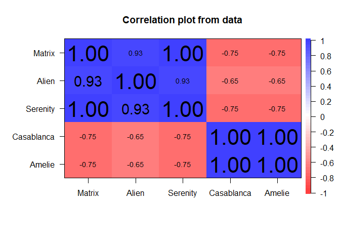

```r
library(psych)
corPlot(A)
```

```r
library("factoextra")
library("FactoMineR")
```

```r
peliculas_pca=PCA(A, graph = F)
peliculas_pca
```

```
## **Results for the Principal Component Analysis (PCA)**
## The analysis was performed on 7 individuals, described by 5 variables
## *The results are available in the following objects:
##
##    name               description
## 1  "$eig"             "eigenvalues"
## 2  "$var"             "results for the variables"
## 3  "$var$coord"       "coord. for the variables"
## 4  "$var$cor"         "correlations variables - dimensions"
## 5  "$var$cos2"        "cos2 for the variables"
## 6  "$var$contrib"     "contributions of the variables"
## 7  "$ind"             "results for the individuals"
## 8  "$ind$coord"       "coord. for the individuals"
## 9  "$ind$cos2"        "cos2 for the individuals"
## 10 "$ind$contrib"     "contributions of the individuals"
## 11 "$call"            "summary statistics"
## 12 "$call$centre"     "mean of the variables"
## 13 "$call$ecart.type" "standard error of the variables"
## 14 "$call$row.w"      "weights for the individuals"
## 15 "$call$col.w"      "weights for the variables"
```

- `"$eig"`
  - Representa los autovalores asociados a cada componente principal.
  - Los autovalores indican la cantidad de varianza que cada componente principal representa. Cuanto más grande es un autovalor, más varianza del conjunto original de datos es capturada por ese componente.
- `"$var"` Proporciona un resumen de los resultados relacionados con las variables.
- `"$var$coord"` Son las coordenadas de las variables en el espacio de los componentes principales. Estas coordenadas ayudan a interpretar la relación entre las variables y cada componente principal.
- `"$var$cor"` Representa las correlaciones entre las variables originales y los componentes principales. Una correlación alta indica que la variable está bien representada por ese componente principal.
- `"$var$cos2"` Es el cuadrado del coseno de los ángulos entre las variables y los componentes principales. Muestra la calidad de representación de las variables en cada componente principal. Un valor cercano a 1 indica una buena representación.
- `"$var$contrib"` Indica cuánto contribuye cada variable a cada componente principal.
- `"$ind"` Proporciona un resumen de los resultados relacionados con las observaciones o individuos.
- `"$ind$coord"` Son las coordenadas de los individuos en el espacio de los componentes principales.
- `"$ind$cos2"` muestra la calidad de representación de los individuos en cada componente principal.
- `"$ind$contrib"` Indica cuánto contribuye cada individuo a cada componente principal.
- `"$call"` Estadísticas resumidas del PCA.
- `"$call$centre"` Es la media de cada variable. El PCA se realiza comúnmente después de centrar (restar la media) los datos.
- `"$call$ecart.type"` Representa la desviación estándar o el error estándar de las variables.
- `"$call$row.w"` Son los pesos asociados a cada individuo.
- `"$call$col.w"` Son los pesos asociados a cada variable.

```r
class(peliculas_pca)
```

```
## [1] "PCA"  "list"
```

```r
peliculas_pca$eig
```

```
##          eigenvalue percentage of variance cumulative percentage of variance
## comp 1 4.270125e+00           8.540250e+01                          85.40250
## comp 2 6.493593e-01           1.298719e+01                          98.38969
## comp 3 8.051566e-02           1.610313e+00                         100.00000
## comp 4 1.464622e-33           2.929243e-32                         100.00000
## comp 5 3.592073e-66           7.184147e-65                         100.00000
```

```r
peliculas_pca$var$coord
```

```
##                 Dim.1     Dim.2       Dim.3         Dim.4         Dim.5
## Matrix      0.9617509 0.2441499  0.12420145  1.035644e-33  0.000000e+00
## Alien       0.9051834 0.3632297 -0.22069699 -4.065142e-49  6.137228e-82
## Serenity    0.9617509 0.2441499  0.12420145 -1.035644e-33 -5.759958e-82
## Casablanca -0.8946615 0.4462091  0.02186887  1.016285e-49 -2.539979e-66
## Amelie     -0.8946615 0.4462091  0.02186887  1.016285e-49  2.539979e-66
```

```r
get_eigenvalue(peliculas_pca)
```

```
##         eigenvalue variance.percent cumulative.variance.percent
## Dim.1 4.270125e+00     8.540250e+01                    85.40250
## Dim.2 6.493593e-01     1.298719e+01                    98.38969
## Dim.3 8.051566e-02     1.610313e+00                   100.00000
## Dim.4 1.464622e-33     2.929243e-32                   100.00000
## Dim.5 3.592073e-66     7.184147e-65                   100.00000
```

```r
peliculas_pca$eig
```

```
##          eigenvalue percentage of variance cumulative percentage of variance
## comp 1 4.270125e+00           8.540250e+01                          85.40250
## comp 2 6.493593e-01           1.298719e+01                          98.38969
## comp 3 8.051566e-02           1.610313e+00                         100.00000
## comp 4 1.464622e-33           2.929243e-32                         100.00000
## comp 5 3.592073e-66           7.184147e-65                         100.00000
```

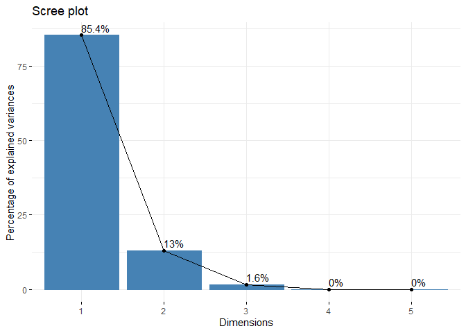

```r
fviz_eig(peliculas_pca, addlabels=T)
```

- Se puede observar tanto en la tabla como en el anterior gráfico que las componentes $1$ y 2 son las más significativas ya que capturan el 98% de las varianzas de las variables.

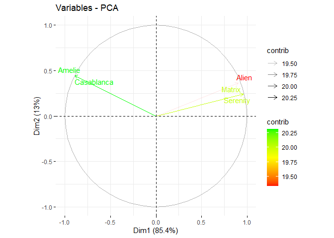

```r
fviz_pca_var(peliculas_pca,repel = T, colvar="cos2", col.var = "contrib", alpha.var = "contrib", gradient.cols=c("#FF0000","#FFFF00","#00FF00"))
```

**Analisis**

```r
library("corrplot")
#get_pca_var(peliculas_pca)
```

```r
#get_pca_var(peliculas_pca)$coord[,1:3]
```

```r
#get_pca_var(peliculas_pca)$contrib[,1:5]
```

```r
#peliculas_pca$var$cos2
```

```r
#corrplot(get_pca_var(peliculas_pca)$cos2)
```

Contribuciónn de cada variable a las componentes principales (cada película) en cada concepto(en cada componente principal)

```r
#colSums(get_pca_var(peliculas_pca)$contrib)
```

```r
#fviz_contrib(peliculas_pca, choice = "var", axes=1)
```

```r
#fviz_contrib(peliculas_pca, choice = "var", axes=2)
```

```r
#fviz_contrib(peliculas_pca, choice = "var", axes=3)
```

```r
#fviz_pca_biplot(peliculas_pca)
```

```r
#A=as.data.frame(A)
```

```r
#library(GGally)
#ggpairs(A)
```

# PCA base Iris

```r
library(dplyr)
data("iris")

iris %>%  head(200) %>%
  select(1:5) %>%
  DT::datatable()
```

|  | Sepal.Length | Sepal.Width | Petal.Length | Petal.Width | Species |
| --- | --- | --- | --- | --- | --- |
| 1 | 5.1 | 3.5 | 1.4 | 0.2 | setosa |
| 2 | 4.9 | 3 | 1.4 | 0.2 | setosa |
| 3 | 4.7 | 3.2 | 1.3 | 0.2 | setosa |
| 4 | 4.6 | 3.1 | 1.5 | 0.2 | setosa |
| 5 | 5 | 3.6 | 1.4 | 0.2 | setosa |
| 6 | 5.4 | 3.9 | 1.7 | 0.4 | setosa |
| 7 | 4.6 | 3.4 | 1.4 | 0.3 | setosa |
| 8 | 5 | 3.4 | 1.5 | 0.2 | setosa |
| 9 | 4.4 | 2.9 | 1.4 | 0.2 | setosa |
| 10 | 4.9 | 3.1 | 1.5 | 0.1 | setosa |

[output cut: 140 more lines]

Elegimos las variables cuantitativas

```r
Iris=iris[,1:4]
```

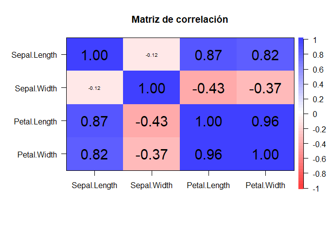

```r
library(psych)

corPlot(Iris, cex = 1.2, main = "Matriz de correlación")
```

```r
Iris_pca=PCA(Iris, graph = F)
```

```r
get_eigenvalue(Iris_pca)
```

```
##       eigenvalue variance.percent cumulative.variance.percent
## Dim.1 2.91849782       72.9624454                    72.96245
## Dim.2 0.91403047       22.8507618                    95.81321
## Dim.3 0.14675688        3.6689219                    99.48213
## Dim.4 0.02071484        0.5178709                   100.00000
```

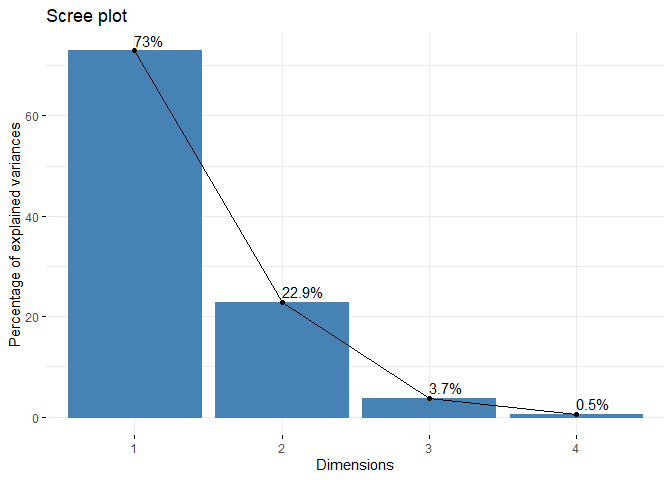

```r
fviz_eig(Iris_pca, addlabels=T)
```

- Podemos observar que los componentes $1$ y $2$ son las más significativas. Capturan casi el 96% de las varianzas de las variables.

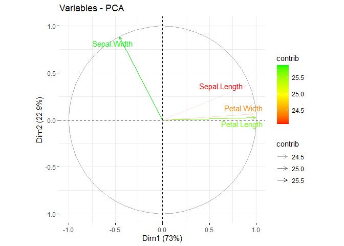

```r
fviz_pca_var(Iris_pca,repel = T, colvar="cos2", col.var = "contrib", alpha.var = "contrib", gradient.cols=c("#FF0000","#FFFF00","#00FF00"))
```

- **Interpretación**
- Podemos notar que el ancho y la longitud de los pétalos están altamente correlacionadas y su variabilidad a través de las tres especies Iris se explica principalmente por el componente $1$(Pétalo), que también explica una gran parte de la variabilidad en la longitud del sépalo.
- La componente principal 2 explica principalmente el ancho del sépalo.

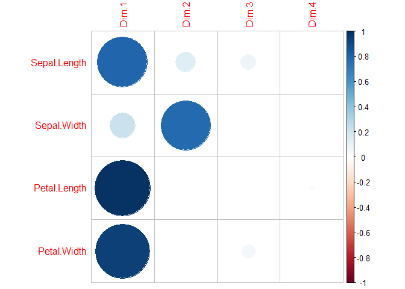

```r
library(corrplot)
corrplot(get_pca_var(Iris_pca)$cos2)
```

- La anterior gráfica corrobora que la dimensión explica muy bien las variables Longitud del petalo, ancho del petalo y longitud del sepalo, mientras que la dimension 2 explica el ancho del sepalo.

### Analisis de variables cualitativas

no se toman en cuanta para pca es para un análisis posterior

```r
iris_pca_anal_sup=PCA(iris, quali.sup = 5, graph = F)
iris_pca_anal_sup$var$coord
```

```
##                   Dim.1      Dim.2       Dim.3       Dim.4
## Sepal.Length  0.8901688 0.36082989 -0.27565767 -0.03760602
## Sepal.Width  -0.4601427 0.88271627  0.09361987  0.01777631
## Petal.Length  0.9915552 0.02341519  0.05444699  0.11534978
## Petal.Width   0.9649790 0.06399985  0.24298265 -0.07535950
```

```r
iris_pca_anal_sup$quali.sup
```

```
## $coord
##                Dim.1      Dim.2       Dim.3       Dim.4
## setosa     -2.224753  0.2889275 -0.04283910 -0.01834076
## versicolor  0.496448 -0.5501705 -0.09612951  0.03034009
## virginica   1.728305  0.2612430  0.13896861 -0.01199933
##
## $cos2
##                Dim.1      Dim.2        Dim.3        Dim.4
## setosa     0.9829895 0.01657917 0.0003644734 6.680665e-05
## versicolor 0.4406515 0.54118069 0.0165219448 1.645816e-03
## virginica  0.9714759 0.02219630 0.0062809398 4.682797e-05
##
## $v.test
##                 Dim.1     Dim.2      Dim.3      Dim.4
## setosa     -11.240362  2.608475 -0.9652043 -1.0999036
## versicolor   2.508258 -4.967011 -2.1658862  1.8195091
## virginica    8.732103  2.358536  3.1310905 -0.7196055
##
## $dist
##     setosa versicolor  virginica
##  2.2439201  0.7478701  1.7534945
##
## $eta2
##             Dim.1     Dim.2      Dim.3      Dim.4
## Species 0.9346162 0.1657182 0.06902197 0.02254243
```

Visualizar todas las variables en un solo gráfico

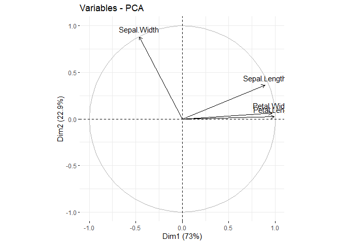

```r
fviz_pca_var(iris_pca_anal_sup)
```

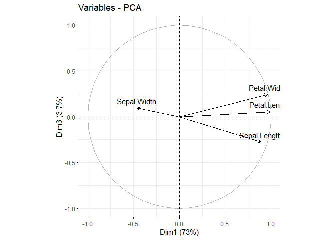

```r
fviz_pca_var(iris_pca_anal_sup, axes=c(1,3), geom = c("arrow", "text") )
```

como mostrar las variables cualitativas, en este caso las competencias

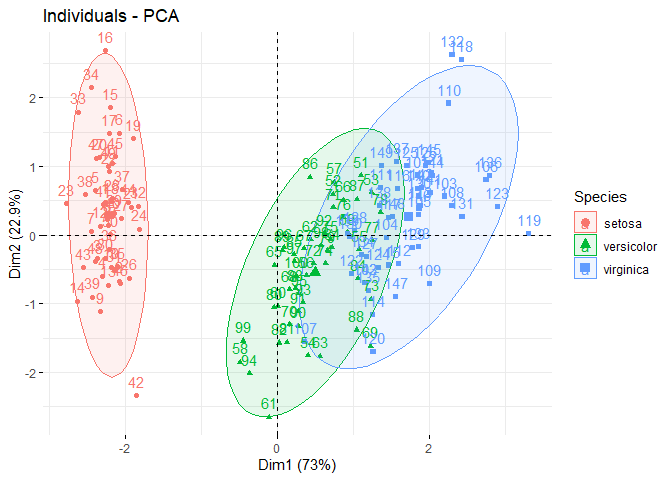

```r
fviz_pca_ind(iris_pca_anal_sup, addEllipses = T, habillage = 5)
```

```r
library(ggplot2)
```

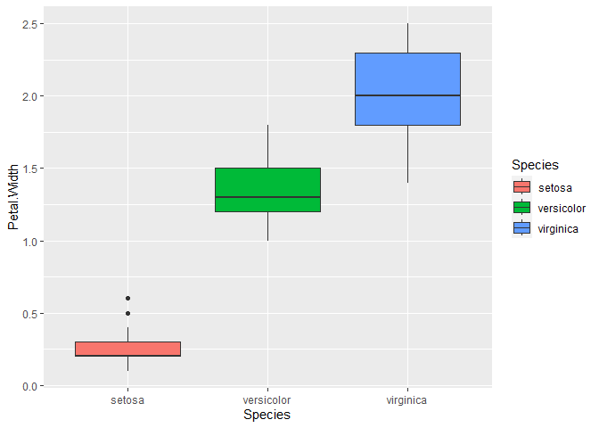

```r
ggplot(data=iris, aes(x=Species, y=Petal.Width, fill=Species))+
  geom_boxplot()
```

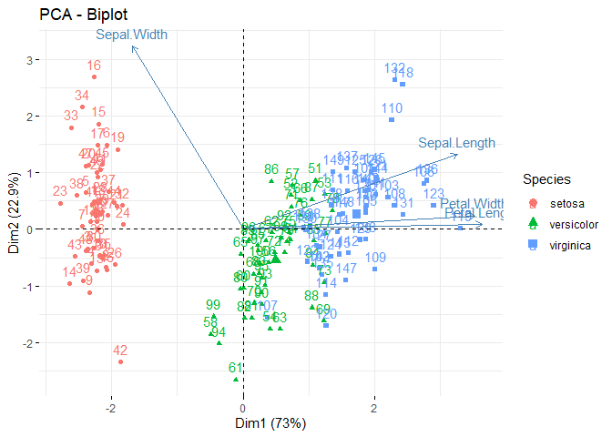

```r
fviz_pca_biplot(iris_pca_anal_sup,  habillage = 5)
```

- En los dos anteriores gráficos observamos que hay una gran diferencia entre las flores iris de la especie setosa y las de las especies versicolor y virginica esta diferencia se da en la dimensión $1$ que representa el ancho y la longitud del petalo y la longitud del sepalo.

A continuación se puede visualizar las correlaciones graficamente de cada una de las variables.

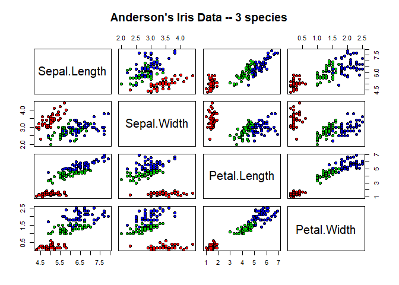

```r
pairs(iris[1:4], main = "Anderson's Iris Data -- 3 species",
      pch = 21, bg = c("red", "green3", "blue")[unclass(iris$Species)])
```

```r
library(ggplot2)
library(GGally)
```

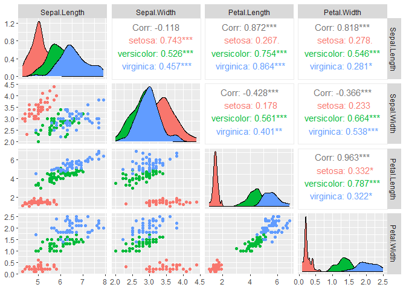

```r
ggpairs(iris[,1:4], mapping = aes(color=iris$Species))
```